# Statistical_Inference_1

Ajith Masthan

May 17, 2020

# Statistical Inference Part-1

## Overview

Explore the exponential distribution in R and compare it with the Central Limit Theorem. The exponential distribution is simulated in R with rexp(n, lambda) where lambda is the rate parameter. The mean and standard deviation of exponential distribution is 1/lambda. lambda = 0.2 is used for all of the simulations. Distribution of averages of 40 exponentials is investigated with a thousand simulations.

## Simulations

```r
# load neccesary libraries
library(ggplot2)

# set constants
lambda <- 0.2 # lambda for rexp
n <- 40 # number of exponetials
numberOfSimulations <- 1000 # number of tests

# set the seed to create reproducability
set.seed(2866)

# run the test resulting in n x numberOfSimulations matrix
exponentialDistributions <- matrix(data=rexp(n * numberOfSimulations, lambda), nrow=numberOfSimulations)
exponentialDistributionMeans <- data.frame(means=apply(exponentialDistributions, 1, mean))
```

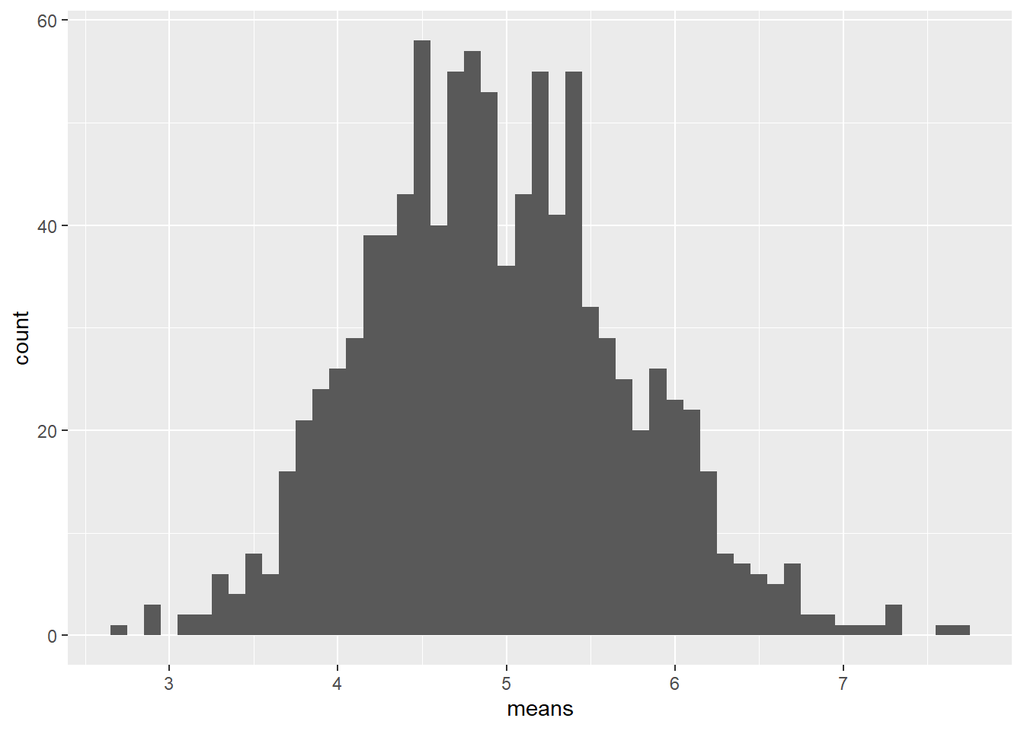

```r
# plot the means
ggplot(data = exponentialDistributionMeans, aes(x = means)) +
  geom_histogram(binwidth=0.1) +
  scale_x_continuous(breaks=round(seq(min(exponentialDistributionMeans$means), max(exponentialDistributionMeans$means), by=1)))
```

## Sample Mean versus Theoretical Mean

The expected mean mu of a exponential distribution of rate lambda is

mu = 1/lambda

```r
mu <- 1/lambda
mu
```

```
## [1] 5
```

X_bar is the average sample mean of 1000 simulations of 40 randomly sampled exponential distributions.

```r
meanOfMeans <- mean(exponentialDistributionMeans$means)
meanOfMeans
```

```
## [1] 4.941941
```

The expected mean is close to average sample mean

## Sample Variance versus Theoretical Variance

sigma = (1/lambda)/sqrt(n)

```r
sd <- 1/lambda/sqrt(n)
sd
```

```
## [1] 0.7905694
```

The variance Var of standard deviation sigma is

Var=square(sigma)

```r
Var <- sd^2
Var
```

```
## [1] 0.625
```

Let Var_x is the variance of the average sample mean of 1000 simulations of 40 randomly sampled exponential distribution with standard deviation sigma_x

```r
sd_x <- sd(exponentialDistributionMeans$means)
sd_x
```

```
## [1] 0.7710459
```

```r
Var_x <- var(exponentialDistributionMeans$means)
Var_x
```

```
## [1] 0.5945119
```

The Standard deviation and Variance are close

## Distribution

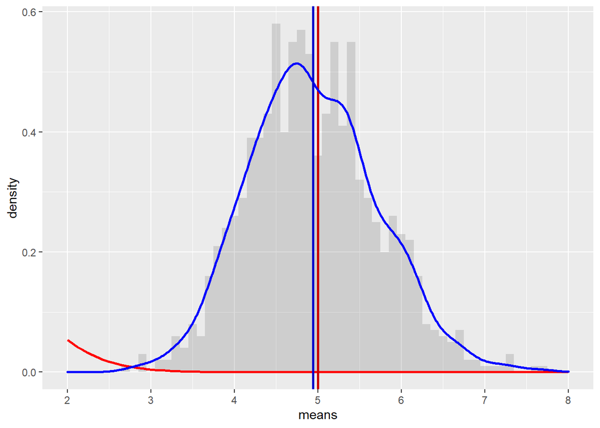

```r
# Plotting the means
ggplot(data = exponentialDistributionMeans, aes(x = means)) +
  geom_histogram(binwidth=0.1, aes(y=..density..), alpha=0.2) +
  stat_function(fun = dnorm, arg = list(mean = mu , sd = sd), colour = "red", size=1) +
  geom_vline(xintercept = mu, size=1, colour="#CC0000") +
  geom_density(colour="blue", size=1) +
  geom_vline(xintercept = meanOfMeans, size=1, colour="#0000CC") +
  scale_x_continuous(breaks=seq(mu-3,mu+3,1), limits=c(mu-3,mu+3))
```